# BE1: Regression linéaire

##Exercice 1:

###1.

```r
ph = read.table(file = "ph.txt", header = TRUE, sep="\t", dec=",")
lm1 = lm(pHcalc_insitu~days, data = ph)
```

Le modèle lm1 est un modèle de régression linéaire de pHcalc_insitu en fonction de days.

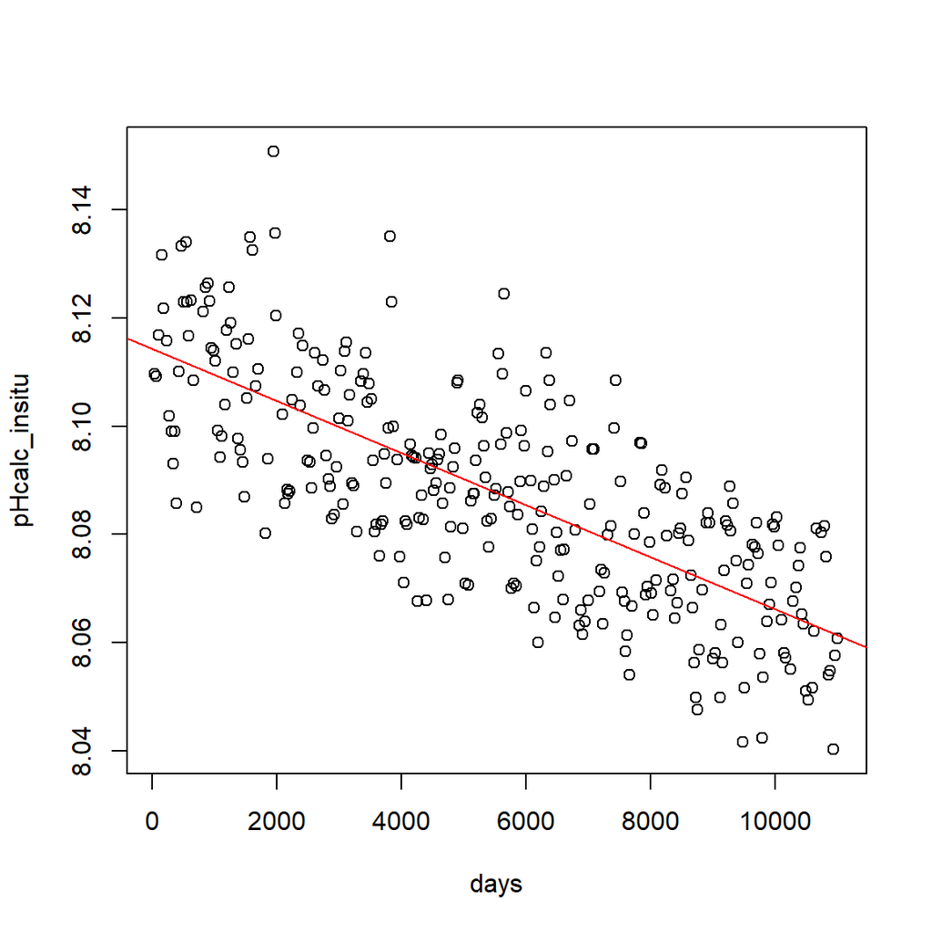

```r
plot(pHcalc_insitu~days, data = ph)
abline(lm1$coefficients, col = 'red')
```

2. Le pourcentage de variance expliquée par cette régression est mesuré par $R^2$.

```r
summary(lm1)
```

```
##
## Call:
## lm(formula = pHcalc_insitu ~ days, data = ph)
##
## Residuals:
##       Min        1Q    Median        3Q       Max
## -0.026969 -0.010493 -0.000187  0.010587  0.045919
##
## Coefficients:
##               Estimate Std. Error t value Pr(>|t|)
## (Intercept)  8.114e+00  1.597e-03 5079.97   <2e-16 ***
## days        -4.801e-06  2.520e-07  -19.05   <2e-16 ***
## ---
## Signif. codes:  0 '***' 0.001 '**' 0.01 '*' 0.05 '.' 0.1 ' ' 1
##
## Residual standard error: 0.01359 on 297 degrees of freedom
##   (9 observations deleted due to missingness)
## Multiple R-squared:  0.5499, Adjusted R-squared:  0.5484
## F-statistic: 362.9 on 1 and 297 DF,  p-value: < 2.2e-16
```

On obtient $R^2=0.5499$.

Or on voit dans l’output de la question b) que la p-value<2e-16<0.05, donc on rejette l’hypothèse $H_0$. On a donc $\beta_1 \neq 0$ et on peut valider le modèle.

###2)

```r
nouvel_individu = data.frame(days = 19000)
prediction_IC = data.frame(predict(lm1, newdata = nouvel_individu, interval = 'confidence', level = 0.95))
prediction_IC
```

```
##        fit      lwr      upr
## 1 8.022966 8.016103 8.029829
```

Avec ce modèle, on peut prévoir un pH de 8.023 en 2050, avec pour intervalle de confiance à 95% [8.016103, 8.029829].

###3)

```r
prediction_IP = data.frame(predict(lm1, newdata = nouvel_individu, interval = 'prediction', level = 0.95))
prediction_IP
```

```
##        fit      lwr      upr
## 1 8.022966 7.995358 8.050575
```

On calcule pour intervalle de prédiction à 95% [7.995358, 8.050575]. Le pH en 2050 pourra donc être observé en dessous de 8.

###4)

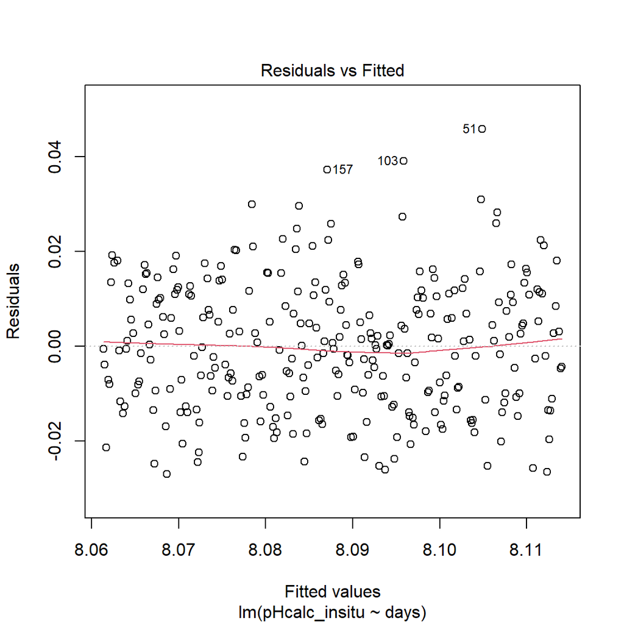

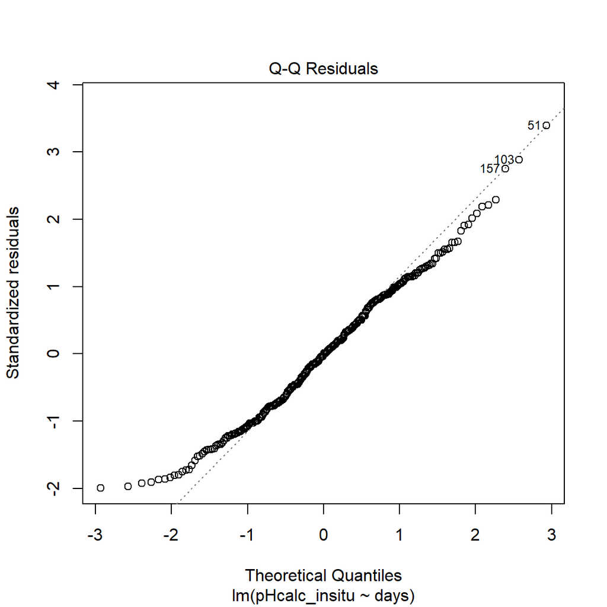

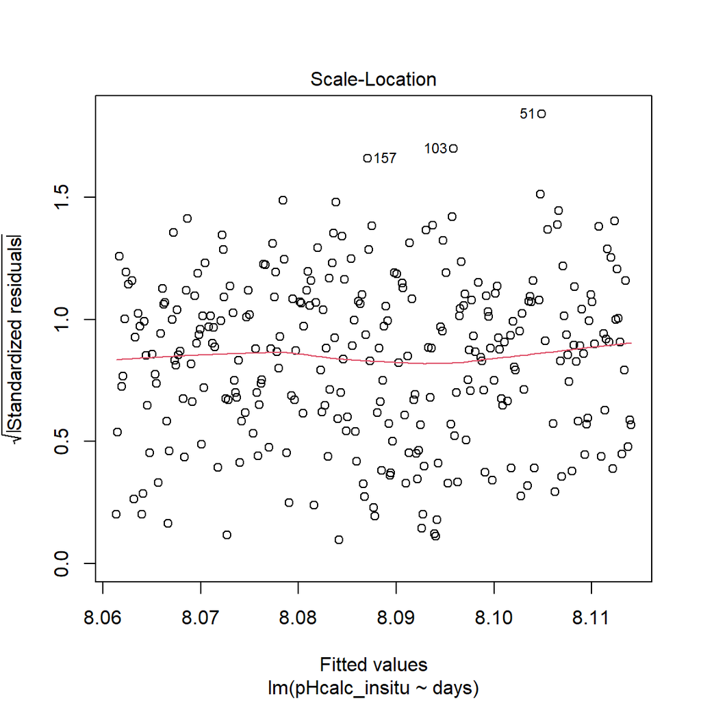

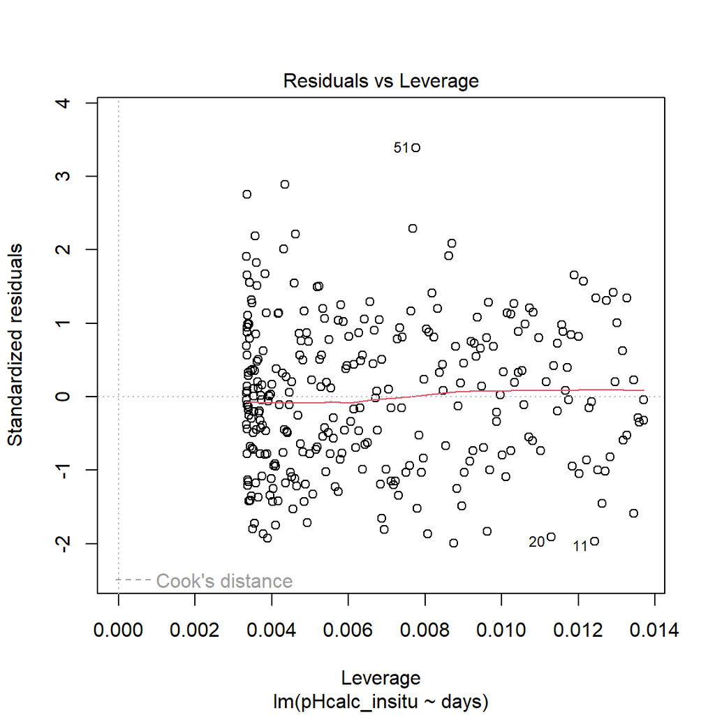

```r
plot(lm1)
```

###5) Pour savoir si l’océan se réchauffe, on peut étudier le modèle de régression linéaire de la température on fonction du temps.

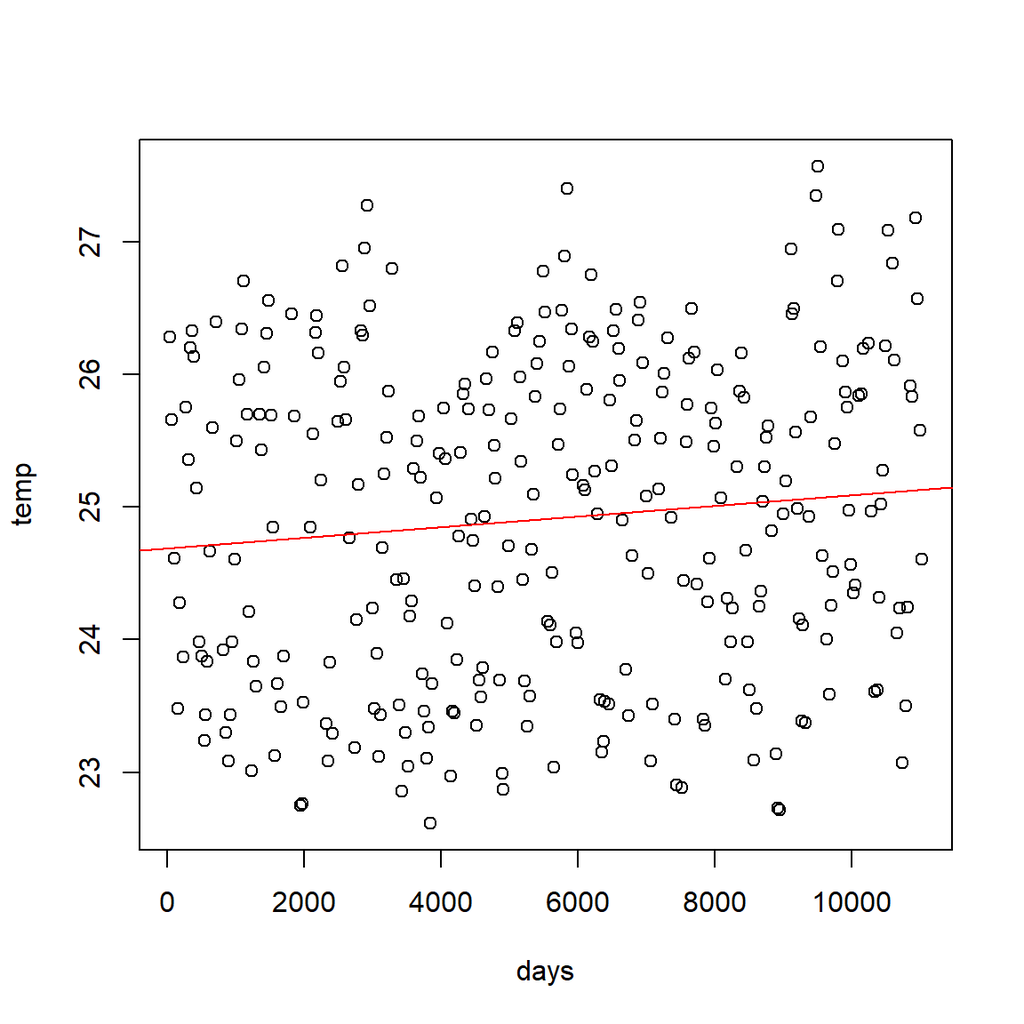

```r
lm2 = lm(temp~days, data = ph)
plot(temp~days, data = ph)
abline(lm2$coefficients, col = 'red')
```

Il paraît ainsi que la température ait une tendance croissante. Toutefois, avant d’arriver à une conclusion, il faut d’abord valider le modèle.

```r
summary(lm2)
```

```
##
## Call:
## lm(formula = temp ~ days, data = ph)
##
## Residuals:
##      Min       1Q   Median       3Q      Max
## -2.33490 -1.04339  0.05254  0.98183  2.49979
##
## Coefficients:
##              Estimate Std. Error t value Pr(>|t|)
## (Intercept) 2.469e+01  1.399e-01  176.49   <2e-16 ***
## days        4.013e-05  2.193e-05    1.83   0.0682 .
## ---
## Signif. codes:  0 '***' 0.001 '**' 0.01 '*' 0.05 '.' 0.1 ' ' 1
##
## Residual standard error: 1.194 on 300 degrees of freedom
##   (6 observations deleted due to missingness)
## Multiple R-squared:  0.01104,    Adjusted R-squared:  0.007743
## F-statistic: 3.349 on 1 and 300 DF,  p-value: 0.06825
```

On observe que la p-value est de 0.0682 > 0.05. On conserve donc $H_0$. Ainsi on ne peut pas valider le modèle, et on ne peut donc pas juger sur la croissance de la température des océans.

Nous savons en revanche que le pH est décroissant avec le temps. Etudions donc le modèle de régression linéaire de la température en fonction du pH.

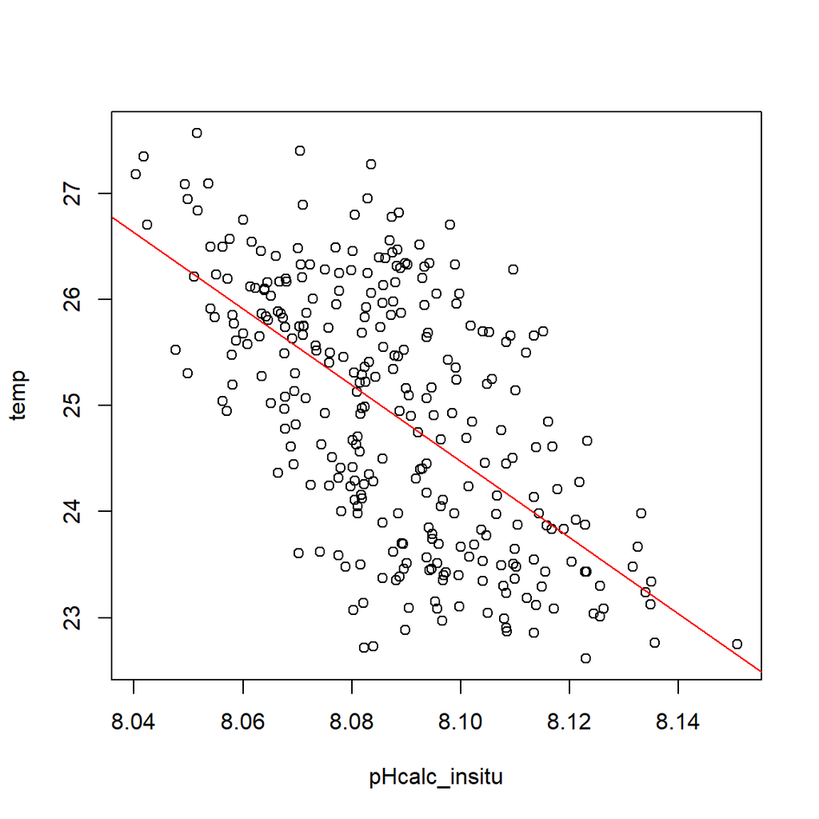

```r
lm3 = lm(temp~pHcalc_insitu, data = ph)
plot(temp~pHcalc_insitu, data = ph)
abline(lm3$coefficients, col = 'red')
```

On observe à première vue que la température décroit lorsque le pH augmente.

On effectue un test de Student pour valider le modèle.

```r
summary(lm3)
```

```
##
## Call:
## lm(formula = temp ~ pHcalc_insitu, data = ph)
##
## Residuals:
##      Min       1Q   Median       3Q      Max
## -2.39717 -0.77155  0.07192  0.68099  2.21512
##
## Coefficients:
##               Estimate Std. Error t value Pr(>|t|)
## (Intercept)    315.441     22.271   14.16   <2e-16 ***
## pHcalc_insitu  -35.922      2.754  -13.04   <2e-16 ***
## ---
## Signif. codes:  0 '***' 0.001 '**' 0.01 '*' 0.05 '.' 0.1 ' ' 1
##
## Residual standard error: 0.9612 on 297 degrees of freedom
##   (9 observations deleted due to missingness)
## Multiple R-squared:  0.3643, Adjusted R-squared:  0.3621
## F-statistic: 170.2 on 1 and 297 DF,  p-value: < 2.2e-16
```